# Choosing A Modelling Method

## Introduction

In order to fit a species distribution model (SDM), we must select a modelling method to relate our response data (e.g., presence-background points) to our covariates (e.g., mean annual temperature). There are multiple modelling method available, so how do we choose the one appropriate for our analysis? Choosing the wrong one can have consequences for our over-arching modelling goal: species conservation.

With an abundance of SDM methods available, it can be difficult to know which to choose. The modelling method we choose primarily depends on the type of data we have and the question we’re asking. Methods for species distribution modelling fall into three broad categories: ‘profile’, ‘regression’, or ‘machine learning’. There are also ensemble models that combine analyses from multiple methods into a single result. Here, we confine our discussion to the regression and machine learning-based methods currently available in `zoon`. The literature refers to the models under these headings, and we keep to convention, but note that there is no fundamental distinction between the two.

In this guide we go into detail about some common modelling methods currently available as modules in `zoon`. For each method we cover compatible data types and the underlying statistical approaches, as well as demonstrate how to fit them in `zoon`.

Throughout this guide our intention is to understand the distribution of the Carolina wren, *Thryothorus ludovicianus*, in North America, and to highlight the differences between modelling methods as we do so. SDMs are frequently used to map predicted species’ distributions, so we will use these to examine the differences between modelling methods. Some things to keep an eye out for are changes in the probability of occurrence, the ‘sharpness’ in transitions from high-to-low probability of occurrence areas, and distributions predicted outside the range of our observation data. Figure 1 below is a visualisation of our data where we have used the `NullModel` module to predict constant occupancy. You can see that our data includes presence-only observation data (red) that is mostly restricted to the eastern USA, and randomly-generated background data (black) across our entire areas of interest.

```r
ext <- extent(c(-138.71, -52.58, 18.15, 54.95)) # define extent of study area

data <- workflow(occurrence = SpOcc("Thryothorus ludovicianus",
                                    extent = ext),
                 covariate = Bioclim(extent = ext),
                 process = Background(1000),
                 model = NullModel,
                 output = PrintOccurrenceMap)
```

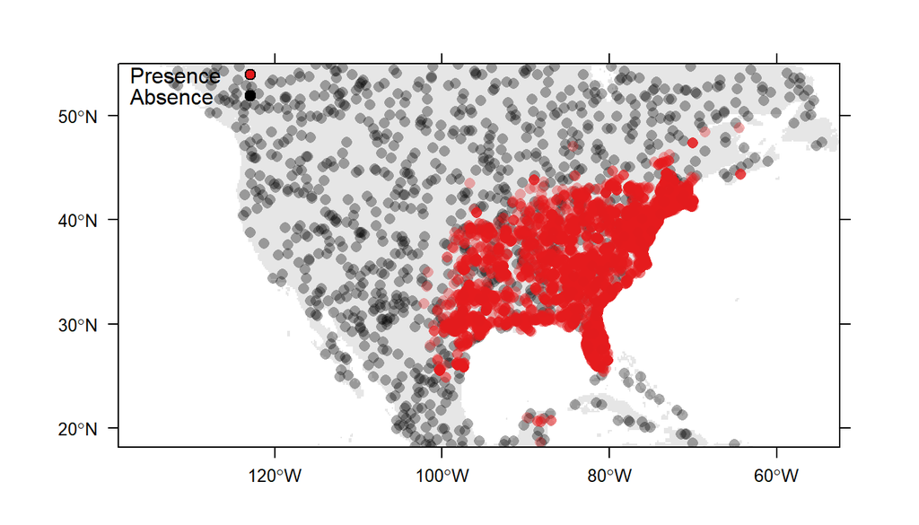

Distribution of presence (red) and background (black) data for the Carolina wren in North America

## Regression-based methods

There are currently two regression-based SDMs available as `zoon` modules: logistic regression and generalised additive models. Regression analyses estimate the statistical relationship between a dependent variable (e.g. presence of a species) and one or more independent variables (e.g. environmental covariates).

Standard linear models assume a linear effect of covariates, $x$, on the response variable, $y$ (see $(1)$). These models assume a linear relationship between the response variable and the covariates, and that the response variables are normally-distributed. In contrast, generalised linear models (GLMs) use ‘link functions’ which relax the assumption of linearity. GLMs let us use non-normally-distributed response variables (such as binary data) by transforming them to be used within the standard linear model framework.

$$y = c + mx (1)$$

### Logistic regression

Logistic regression is onesuch generalised linear model (GLM) that can be fit to presence/background or presence/absence data. It uses the *logit* link function to estimate the probability of a binary response variable (e.g. species presence/absence) based on its relationship with our predictor covariates. Logistic regression estimates one regression coefficient ($\beta$ in the $(2)$) for each covariate using maximum likelihood estimation. We also estimate an $Intercept$ term ($c$ in $(1)$) like in a standard linear model.

$$logit(Pr(Occurrence)) = Intercept + \beta_1Covariate_1 + \beta_2Covariate_2 + \beta_3Covariate_3 (2)$$

The left-hand side of equation $(2)$ is the transformation of the response variable using the link function. The right-hand side of this equation is known as the *linear predictor*.

In `zoon`, we can estimate a species distribution using logistic regression by choosing the `LogisticRegression` model module in our `zoon` `workflow`. `LogisticRegression` uses the `glm` package to fit our model. Now lets use `LogisticRegression` to model the distribution of the Carolina wren:

```r
logistic <- workflow(occurrence = SpOcc("Thryothorus ludovicianus",
                                        extent = ext),
                     covariate = Bioclim(extent = ext),
                     process = Background(1000),
                     model = LogisticRegression,
                     output = PrintMap)
```

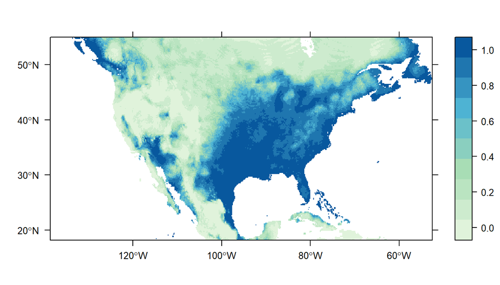

Predicted Carolina wren distribution map from the logistic regression SDM.

In Figure 2 we can see our logistic regression model predicts a high probability of occurrence in eastern USA which broadly matches the distribution of our presence points. There are also patches of high probability of occurrence in western USA that likely represent areas of suitable habitat for the Carolina wren that it does not have the dispersal ability to reach. These patches are selected because their environmental conditions are similar to the location of our presence locations.

### Generalised additive model

Generalised additive models (GAMs) are similar to GLMs but allow more flexibility. Fitting a GAM for binary data (presence-background or presence-absence) is done using a logit link function. Different link functions allows us to use different types of data, e.g. a log link function for abundance data. The main difference between GAMs and GLMs is that GAMs do not estimate regression coefficients. That is, GAMs are non-parametric - without estimated coefficients. Instead, the *linear predictor* is the sum of a set of *smoothing functions* (see $(3)$ below). Using smoothing functions we can fit complex, non-linear relationships between our dependent and independent covariates.

$$logit(Pr(Occurrence)) = Intercept + f_1(Covariate_1) + f_2(Covariate_2) + f_3(Covariate_3) (3)$$

When we use smoothing functions without restrictions, however, it is possible to *overfit* the model to our data. Models that are overfit model the noise in the dataset instead of the underlying relationships with covariates. This leads to poor predictive ability since they respond to irrelevant variations in the data. To avoid this GAMs use *penalised likelihood maximisation* which penalises the model for each additional covariate/smoothing function pair. This balances a trade-off between including enough smoothing functions to explain environmental relationships (or increasing ‘wiggliness’) and too many smoothing functions increasing ‘badness-of-fit’.

In `zoon`, the `mgcv` model module fits a GAM using the `mgcv` package. To fit a GAM we need to define a couple of parameters that determine how complex the linear predictor can be. Specifically, we define the maximum degrees of freedom, $k$, and the *penalised smoothing basis*, $bs$. Together these parameters balance the model’s explanation of the data with the risk of overfitting the model to the dataset. You can find more details on how to define these parameters using `?mgcv::choose.k` and `?mgcv::smooth.terms`.

Here we fit a GAM (using the default settings of $k$ and $bs$) in our `workflow` to model the Carolina wren distribution:

```r
GAM <- workflow(occurrence = SpOcc("Thryothorus ludovicianus",
                                   extent = ext),
                covariate = Bioclim(extent = ext),
                process = Background(1000),
                model = mgcv(k = -1,
                             bs = "tp"),
                output = PrintMap)
```

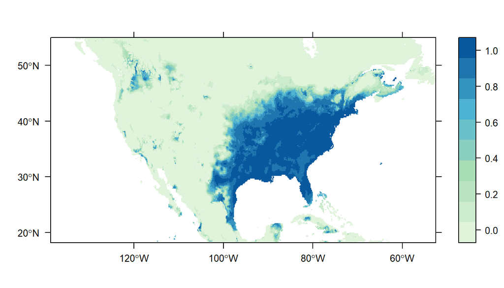

Predicted Carolina wren distribution map for the generalised additive model SDM

Figure 3 shows the predicted distribution of the Carolina wren from our GAM. Like our logistic regression SDM there is a large patch of high probability of occurrence in the eastern USA that overlaps the locations of our presence records. In contrast to the logistic regression SDM, however, areas with high predicted probabilities of occurrence are much more constrained to the eastern USA. Locales such as California, The Bahamas, Nova Scotia, and British Columbia have markedly lower probabilities of occurrence.

## Machine learning methods

Machine learning is a field of computer science where modelling algorithms iteratively learn from data without being explicitly programmed where in the data to look. This is in contast to regression models like GLMs and GAMs which find relationships between specified variables.

### MaxEnt/MaxNet

MaxEnt is one of the most widely used SDM modelling methods (Elith *et al.* 2011). Unlike GLMs and GAMs, which can be used for either presence-absence or presence-background data, MaxEnt can only be used for presence-background data.

MaxEnt uses maximum entropy estimation to fit a model to our data. Maximum entropy estimation compares two probability densities of our data. First, the probability density of our environmental covariates across the landscape where the species is present, $f_1(z)$. Second, the probability density of the covariates for our background points, $f(z)$. The estimated ratio of $f_1(z)/f(z)$ provides insight on which covariates are important, and establishes the relative suitability of sites.

MaxEnt must estimate $f_1(z)$ such that it is consistent with our occurrence data, but as there are many possible distributions that can accomplish this it chooses the one closest to $f(z)$. Minimising the difference between the two probability densities is sensible as, without species absence data, we have no information to guide our expectation of species’ preferences for one particular environment over another.

The distance from $f(z)$ represents the relative entropy of $f_1(z)$ with respect to $f(z)$. Minimising the relative entropy is equivalent to maximising the entropy (hence, MaxEnt) of the ratio $f_1(z)/f(z)$. This model can be described as maximising entropy in geographic space, or minimising entropy in environmental space.

Like GLMs and GAMs, MaxEnt is also prone to overfitting so must estimate coefficients in a manner that balances this risk with the above constraints. This is achieved using regularisation, which can be thought of as shrinking the coefficients towards zero by penalising them to balance model fit and complexity. Thus, MaxEnt can be seen as fitting a penalised maximum likelihood model.

The `MaxEnt` module uses the `maxent()` function in the `dismo` package, and requires MaxEnt be installed on our computer. The `zoon` helper function `GetMaxEnt()` is available to help with this installation. In this example we will use `MaxNet` as a subsitute for `MaxEnt` due to common difficulties in downloading MaxEnt. The `MaxNet` module uses the `maxnet` R package to fit maximum entropy models without requiring the user to install the MaxEnt java executable file.

Now lets model the Carolina wren distribution using the `MaxNet` module:

```r
MaxNet <- workflow(occurrence = SpOcc("Thryothorus ludovicianus",
                                      extent = ext),
                   covariate = Bioclim(extent = ext),
                   process = Background(1000),
                   model = MaxNet,
                   output = PrintMap)
```

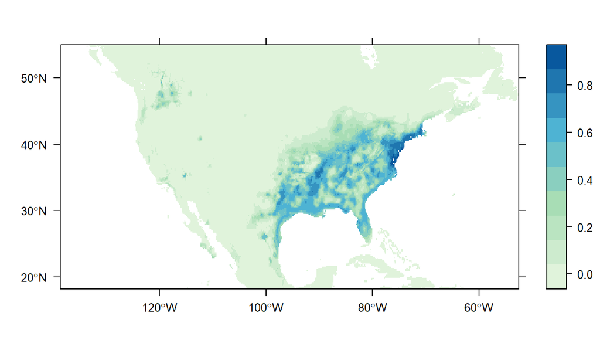

Predicted Carolina wren distribution map for the MaxNet SDM

The SDM for the Carolina wren using `MaxNet` (Figure 4) is markedly different from both regression-based methods. The probability of occurrence within the range of our presence points is considerably smaller than for the regression-based SDMs. There is also a reduced amount of non-zero predictions outside of the range of our presence points, and those that remain have lower probability.

### RandomForest

In contrast to the previous SDMs, which fit a single model, a random forest model (RF) is an ensemble model. That is, it produces a single prediction model in the form of an ensemble of weak prediction models. Put more simply, the core of this idea is that it is easier to build and average multiple rules of thumb than to find one accurate prediction rule.

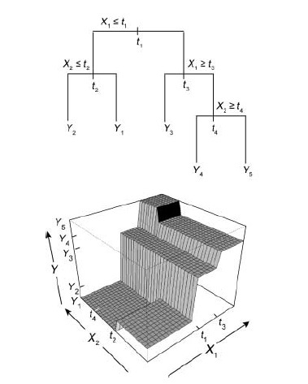

A single decision tree (upper panel), with a response Y, two predictor variables, X1 and X2 and split points t1 , t2 , etc. The bottom panel shows its prediction surface (after Hastie et al. 2001). Image sourced from Elith *et al.* (2008)

RF SDMs independently fit multiple decision trees (normally hundreds or thousands) to bootstrapped samples of our data. Bootstrapping involves re-sampling our data with replacement for each decision tree. The final output of an RF SDM is the mean prediction of all of the individual trees. This corrects the tendency of decision trees to over-fit our data as the bootstrapping process decreases the variance of the model without increasing the bias.

The `RandomForest` module can be fit to presence-background or presence-absence data.

Here we model the distribution of the Carolina wren using the `RandomForest` module using the following `workflow`:

```r
RandomForest <- workflow(occurrence = SpOcc("Thryothorus ludovicianus",
                                            extent = ext),
                         covariate = Bioclim(extent = ext),
                         process = Background(1000),
                         model = RandomForest,
                         output = PrintMap)
```

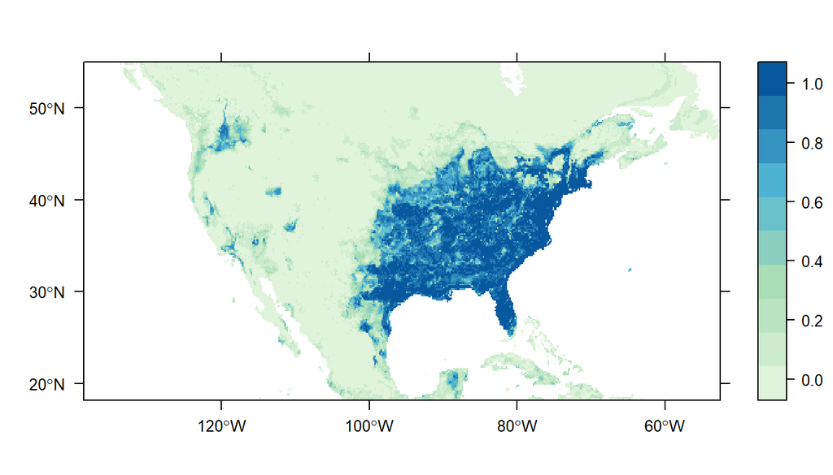

Predicted Carolina wren distribution map for the random forest model.

### Boosted regression trees

Like RF models, Boosted regression trees (BRTs) produce a prediction model in the form of an ensemble of weak prediction models. BRTs are also known as gradient boosting machines or generalised boosting models (GBM), but BRT is the name most commonly used in the SDM context.

In contrast to RF models, where each tree is independent, BRTs use the *boosting* technique to combine large numbers of trees in an adaptive manner to improve predictive performance. Boosting is an iterative procedure that fits each subsequent tree to target the largest amount of unexplained variance from the preceeding trees. This gradually increase the emphasis on observations modelled poorly by existing trees.

The `GBM` module fits a BRT SDM using the `gbm` package. It can be fit to both presence-background and presence-absence datasets. This requires us to set several tuning parameters to control model complexity:

- `max.trees`: The maximum number of trees. This is equivalent to the maximum number of iterations in the model.
- `interaction.depth`: The maximum depth of each tree. This controls the number of nodes (or splits) allowed in the decision trees.
- `shrinkage`: The learning rate/shrinkage factor of the model. This determines the contribution of each tree to the final model average.

Now we can fit a BRT model with the `GBM` module (with the default values for `max.trees`, `interaction.depth`, and `shrinkage`) to our Carolina wren data. This model can be fit using the following call in your `workflow`:

```r
BRT <- workflow(occurrence = SpOcc("Thryothorus ludovicianus",
                                   extent = ext),
                covariate = Bioclim(extent = ext),
                process = Background(1000),
                model = GBM(max.trees = 1000,
                            interaction.depth = 5,
                            shrinkage = 0.001),
                output = PrintMap)
```

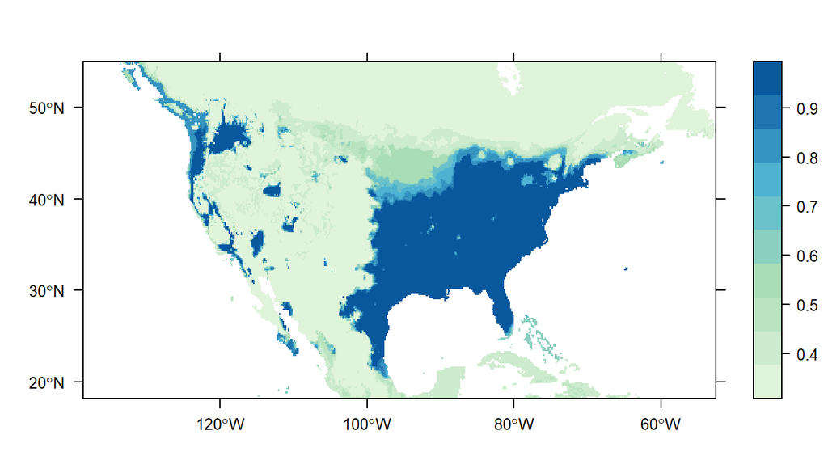

Predicted Carolina wren distribution map for the boosted regresion tree SDM

The `XGBoost` software is increasingly used in machine learning applications for fitting BRTs to very large datasets. This is a re-implementation of the BRT principles designed around maximising computational efficiency. You can use the `MachineLearn` module to fit BRT models with XGBoost by replacing the model module above with: `MachineLearn(method = 'xgbTree')`.

## Choosing a modelling method

The most common SDM modelling methods have been highlighted above, but the question remains about whih method to choose. In short, there are no set rules to determine which method you should use. The way that the methods operate can rule some options out. For example, if you have presence-absence data you wouldn’t use MaxEnt (which only accepts presence-background data), or if you cared about inference more than prediction you would possibly pick a GLM-based method over a decision tree-based one. Even after making some of these decisions you would still have multiple methods to pick from, and while there *may* a ‘best’ method there is no expert consensus. One option is to try multiple options and determine which one best fits your data, or combine multiple methods as part of an ensemble model. Choice of modelling method or methods is an important aspect of species distribution modelling, and is at least partly dependent on the type of analysis you are trying to perform. This guide has outlined the options available, but ultimately the choice of modelling method is up to you.

Elith, J., Leathwick, J.R. & Hastie, T. (2008). A working guide to boosted regression trees. *Journal of Animal Ecology*, **77**, 802–813.

Elith, J., Phillips, S.J., Hastie, T., Dudík, M., Chee, Y.E. & Yates, C.J. (2011). A statistical explanation of maxent for ecologists. *Diversity and Distributions*, **17**, 43–57.